# Creditcard Analysis

DccLxxVii

November 26, 2019

# Load libraries

```r
suppressMessages(library(reshape2))
# suppressMessages(library(tidyverse))
suppressMessages(library(DataExplorer))
#for pretty visualization
suppressMessages(library(ggplot2))
suppressMessages(library("gridExtra"))
library(grid)
library(ggplot2)
library(dplyr)
library(readr)
#for identifying optimal number of clusters
library("NbClust")

#cluster visualization
library("cluster")
```

# 1. INTRODUCTION

Data Science assignment: EDA, Clustering and ANN

### DATA INTRODUCTION (SOURCE:KAGGLE)

The dataset contains transactions made by credit cards in September 2013 by European cardholders. This dataset presents transactions that occurred in two days, where we have 492 frauds out of 284,807 transactions. The dataset is highly unbalanced, the positive class (frauds) account for 0.172% of all transactions.

It contains only numerical input variables which are the result of a PCA transformation. Unfortunately, due to confidentiality issues, we cannot provide the original features and more background information about the data. Features V1, V2, … V28 are the principal components obtained with PCA, the only features which have not been transformed with PCA are ‘Time’ and ‘Amount’. Feature ‘Time’ contains the seconds elapsed between each transaction and the first transaction in the dataset. The feature ‘Amount’ is the transaction Amount, this feature can be used for example-dependant cost-senstive learning. Feature ‘Class’ is the response variable and it takes value 1 in case of fraud and 0 otherwise.

# 2. METHODS

## EXPLORATORY DATA ANALYSIS (EDA)

#### 1. Loading Data

```r
CC_Data <- read_csv("/home/dcclxxvii/Data/creditcard.csv")
```

##### 1a. Checking for missing values

View head

```r
head(CC_Data)
```

```
## # A tibble: 6 x 31
##    Time     V1      V2    V3     V4      V5      V6      V7      V8     V9
##   <dbl>  <dbl>   <dbl> <dbl>  <dbl>   <dbl>   <dbl>   <dbl>   <dbl>  <dbl>
## 1     0 -1.36  -0.0728 2.54   1.38  -0.338   0.462   0.240   0.0987  0.364
## 2     0  1.19   0.266  0.166  0.448  0.0600 -0.0824 -0.0788  0.0851 -0.255
## 3     1 -1.36  -1.34   1.77   0.380 -0.503   1.80    0.791   0.248  -1.51
## 4     1 -0.966 -0.185  1.79  -0.863 -0.0103  1.25    0.238   0.377  -1.39
## 5     2 -1.16   0.878  1.55   0.403 -0.407   0.0959  0.593  -0.271   0.818
## 6     2 -0.426  0.961  1.14  -0.168  0.421  -0.0297  0.476   0.260  -0.569
## # … with 21 more variables: V10 <dbl>, V11 <dbl>, V12 <dbl>, V13 <dbl>,
## #   V14 <dbl>, V15 <dbl>, V16 <dbl>, V17 <dbl>, V18 <dbl>, V19 <dbl>,
## #   V20 <dbl>, V21 <dbl>, V22 <dbl>, V23 <dbl>, V24 <dbl>, V25 <dbl>,
## #   V26 <dbl>, V27 <dbl>, V28 <dbl>, Amount <dbl>, Class <dbl>
```

View tail

```r
tail(CC_Data)
```

```
## # A tibble: 6 x 31
##     Time      V1      V2     V3     V4      V5     V6      V7     V8     V9
##    <dbl>   <dbl>   <dbl>  <dbl>  <dbl>   <dbl>  <dbl>   <dbl>  <dbl>  <dbl>
## 1 172785   0.120  0.931  -0.546 -0.745  1.13   -0.236  0.813   0.115 -0.204
## 2 172786 -11.9   10.1    -9.83  -2.07  -5.36   -2.61  -4.92    7.31   1.91
## 3 172787  -0.733 -0.0551  2.04  -0.739  0.868   1.06   0.0243  0.295  0.585
## 4 172788   1.92  -0.301  -3.25  -0.558  2.63    3.03  -0.297   0.708  0.432
## 5 172788  -0.240  0.530   0.703  0.690 -0.378   0.624 -0.686   0.679  0.392
## 6 172792  -0.533 -0.190   0.703 -0.506 -0.0125 -0.650  1.58   -0.415  0.486
## # … with 21 more variables: V10 <dbl>, V11 <dbl>, V12 <dbl>, V13 <dbl>,
## #   V14 <dbl>, V15 <dbl>, V16 <dbl>, V17 <dbl>, V18 <dbl>, V19 <dbl>,
## #   V20 <dbl>, V21 <dbl>, V22 <dbl>, V23 <dbl>, V24 <dbl>, V25 <dbl>,
## #   V26 <dbl>, V27 <dbl>, V28 <dbl>, Amount <dbl>, Class <dbl>
```

View Columns

```r
names(CC_Data)
```

```
##  [1] "Time"   "V1"     "V2"     "V3"     "V4"     "V5"     "V6"     "V7"
##  [9] "V8"     "V9"     "V10"    "V11"    "V12"    "V13"    "V14"    "V15"
## [17] "V16"    "V17"    "V18"    "V19"    "V20"    "V21"    "V22"    "V23"
## [25] "V24"    "V25"    "V26"    "V27"    "V28"    "Amount" "Class"
```

Advances in viewing the data summary Lets see if the data has missing values

```r
introduce(CC_Data)
```

```
## # A tibble: 1 x 9
##     rows columns discrete_columns continuous_colu… all_missing_col…
##    <int>   <int>            <int>            <int>            <int>
## 1 284807      31                0               31                0
## # … with 4 more variables: total_missing_values <int>, complete_rows <int>,
## #   total_observations <int>, memory_usage <dbl>
```

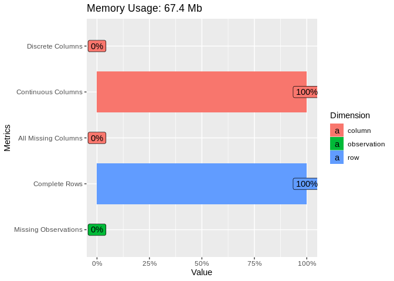

```r
plot_intro(CC_Data)
```

##### Determining the missing value

```r
for (Var in names(CC_Data)) {
    missing <- sum(is.na(CC_Data[,Var]))
    if (missing > 0) {
        print(c(Var,missing))
    }
}
```

##### 1b. Checking for constant features

```r
flag <- FALSE

for (f in names(CC_Data)) {
  if (length(unique(CC_Data[[f]])) == 1) {
    cat(f, "\n")
     flag <- TRUE
  }
}

if (flag == FALSE){
     print ("no variable found to be constant")
}
```

```
## [1] "no variable found to be constant"
```

##### 1c. Checking for equal columns

```r
flag <- FALSE
features_pair <- combn(names(CC_Data), 2, simplify = F)
for(pair in features_pair) {
  f1 <- pair[1]
  f2 <- pair[2]

      if (all(CC_Data[[f1]] == CC_Data[[f2]])) {
      cat(f1, "and", f2, "are equals.\n")
           flag <- TRUE
    }
}

if (flag == FALSE){
     print ("No variables found as equal")
}
```

```
## [1] "No variables found as equal"
```

##### 1d. Data cleansing

```r
CC_Data <- na.omit((CC_Data))
```

#### 2. Summary Statistics

First lets look at the summary statistics of all variable

```r
summary(CC_Data)
```

```
##       Time              V1                  V2                  V3
##  Min.   :     0   Min.   :-56.40751   Min.   :-72.71573   Min.   :-48.3256
##  1st Qu.: 54202   1st Qu.: -0.92037   1st Qu.: -0.59855   1st Qu.: -0.8904
##  Median : 84692   Median :  0.01811   Median :  0.06549   Median :  0.1799
##  Mean   : 94814   Mean   :  0.00000   Mean   :  0.00000   Mean   :  0.0000
##  3rd Qu.:139320   3rd Qu.:  1.31564   3rd Qu.:  0.80372   3rd Qu.:  1.0272
##  Max.   :172792   Max.   :  2.45493   Max.   : 22.05773   Max.   :  9.3826
##        V4                 V5                   V6                 V7
##  Min.   :-5.68317   Min.   :-113.74331   Min.   :-26.1605   Min.   :-43.5572
##  1st Qu.:-0.84864   1st Qu.:  -0.69160   1st Qu.: -0.7683   1st Qu.: -0.5541
##  Median :-0.01985   Median :  -0.05434   Median : -0.2742   Median :  0.0401
##  Mean   : 0.00000   Mean   :   0.00000   Mean   :  0.0000   Mean   :  0.0000
##  3rd Qu.: 0.74334   3rd Qu.:   0.61193   3rd Qu.:  0.3986   3rd Qu.:  0.5704
##  Max.   :16.87534   Max.   :  34.80167   Max.   : 73.3016   Max.   :120.5895
##        V8                  V9                 V10                 V11
##  Min.   :-73.21672   Min.   :-13.43407   Min.   :-24.58826   Min.   :-4.79747
##  1st Qu.: -0.20863   1st Qu.: -0.64310   1st Qu.: -0.53543   1st Qu.:-0.76249
##  Median :  0.02236   Median : -0.05143   Median : -0.09292   Median :-0.03276
##  Mean   :  0.00000   Mean   :  0.00000   Mean   :  0.00000   Mean   : 0.00000
##  3rd Qu.:  0.32735   3rd Qu.:  0.59714   3rd Qu.:  0.45392   3rd Qu.: 0.73959
##  Max.   : 20.00721   Max.   : 15.59500   Max.   : 23.74514   Max.   :12.01891
##       V12                V13                V14                V15
##  Min.   :-18.6837   Min.   :-5.79188   Min.   :-19.2143   Min.   :-4.49894
##  1st Qu.: -0.4056   1st Qu.:-0.64854   1st Qu.: -0.4256   1st Qu.:-0.58288
##  Median :  0.1400   Median :-0.01357   Median :  0.0506   Median : 0.04807
##  Mean   :  0.0000   Mean   : 0.00000   Mean   :  0.0000   Mean   : 0.00000
##  3rd Qu.:  0.6182   3rd Qu.: 0.66251   3rd Qu.:  0.4931   3rd Qu.: 0.64882
##  Max.   :  7.8484   Max.   : 7.12688   Max.   : 10.5268   Max.   : 8.87774
##       V16                 V17                 V18
##  Min.   :-14.12985   Min.   :-25.16280   Min.   :-9.498746
##  1st Qu.: -0.46804   1st Qu.: -0.48375   1st Qu.:-0.498850
##  Median :  0.06641   Median : -0.06568   Median :-0.003636
##  Mean   :  0.00000   Mean   :  0.00000   Mean   : 0.000000
##  3rd Qu.:  0.52330   3rd Qu.:  0.39968   3rd Qu.: 0.500807
##  Max.   : 17.31511   Max.   :  9.25353   Max.   : 5.041069
##       V19                 V20                 V21
##  Min.   :-7.213527   Min.   :-54.49772   Min.   :-34.83038
##  1st Qu.:-0.456299   1st Qu.: -0.21172   1st Qu.: -0.22839
##  Median : 0.003735   Median : -0.06248   Median : -0.02945
##  Mean   : 0.000000   Mean   :  0.00000   Mean   :  0.00000
```

[output cut: 8 more lines]

```
##  Max.   : 10.503090   Max.   : 22.52841   Max.   : 4.58455
##       V25                 V26                V27
##  Min.   :-10.29540   Min.   :-2.60455   Min.   :-22.565679
##  1st Qu.: -0.31715   1st Qu.:-0.32698   1st Qu.: -0.070840
##  Median :  0.01659   Median :-0.05214   Median :  0.001342
##  Mean   :  0.00000   Mean   : 0.00000   Mean   :  0.000000
##  3rd Qu.:  0.35072   3rd Qu.: 0.24095   3rd Qu.:  0.091045
##  Max.   :  7.51959   Max.   : 3.51735   Max.   : 31.612198
##       V28                Amount             Class
##  Min.   :-15.43008   Min.   :    0.00   Min.   :0.000000
##  1st Qu.: -0.05296   1st Qu.:    5.60   1st Qu.:0.000000
##  Median :  0.01124   Median :   22.00   Median :0.000000
##  Mean   :  0.00000   Mean   :   88.35   Mean   :0.001728
##  3rd Qu.:  0.07828   3rd Qu.:   77.17   3rd Qu.:0.000000
##  Max.   : 33.84781   Max.   :25691.16   Max.   :1.000000
```

##### Factoring the Class variable

```r
# Creating factor
CC_Data <- CC_Data %>%
     mutate(Class = as.factor(Class))
levels(CC_Data$Class) <- c('Normal', 'Fraud')

#ploting
table(CC_Data$Class)
```

```
##
## Normal  Fraud
## 284315    492
```

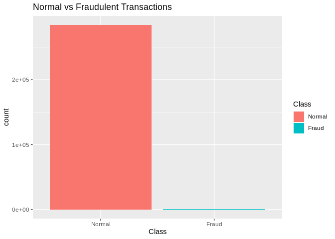

```r
ggplot(CC_Data)+
     geom_bar(aes(x = Class, fill = Class))+ggtitle("Normal vs Fraudulent Transactions")
```

- The data is highly unbalanced as there are 492 fraud transactions compared to 284,315 clean transactions

#####Creating two separate data sets for Fraud and Clean transactions ***

```r
fraudData <- subset(CC_Data,Class=='Fraud')
notFraudData <- subset(CC_Data,Class=='Normal')
```

#### 3. Exploring if Fraud Transactions occur at specific time?

Time is defined as number of seconds elapsed between this transaction and the first transaction in the dataset

```r
# create new variable: night, based on Time variable
CC_Data_time<-na.omit(read_csv("/home/dcclxxvii/Data/creditcard.csv"))
CC_Data_time$Night <- as.factor((floor(CC_Data_time$Time/60/60)%%24 <= 9)*1)
```

#### Transactions divided per time of day

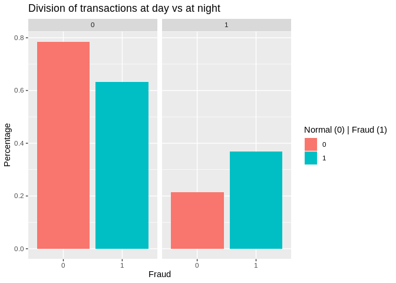

```r
toPlot <- CC_Data_time
toPlot$factClass <- as.factor(CC_Data_time$Class)
toPlot <- table(toPlot$Night, toPlot$factClass)
toPlot <- melt(toPlot)
toPlot$value[toPlot$Var2==0] = toPlot$value[toPlot$Var2==0]/sum(toPlot$value[toPlot$Var2==0])
toPlot$value[toPlot$Var2==1] = toPlot$value[toPlot$Var2==1]/sum(toPlot$value[toPlot$Var2==1])
names(toPlot) <- c("IsNight", "Fraud", "Percentage")
toPlot$Fraud <-as.factor(toPlot$Fraud)
ggplot(toPlot, aes(x=Fraud, y=Percentage, fill=Fraud))+geom_bar(stat="identity")+
  facet_grid(~IsNight)+
  ggtitle("Division of transactions at day vs at night")+
  scale_fill_discrete(name="Normal (0) | Fraud (1)")
```

- Fraud transactions are more likely to happen at night, comparing to normal transactions.
- Normal transactions are more likely to happen during the day than during the night
- Fraud transactions are more likely to happen during the day than during the night

#### Normal and Fraud transactions variation over time

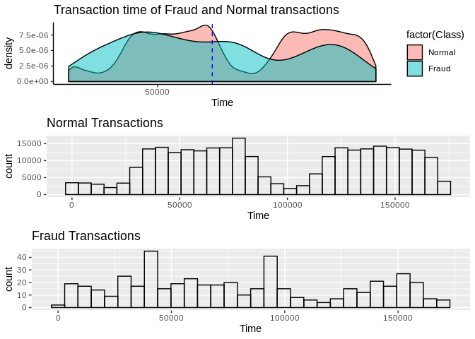

```r
p1 <- ggplot(notFraudData, aes(x = Time)) +
        geom_histogram(fill="light blue", colour = "black") + labs(title=expression("Normal Transactions"))

p2 <- ggplot(fraudData, aes(x = Time)) +
        geom_histogram(fill="light green", colour = "black") + labs(title=expression("Fraud Transactions"))

p3 <- ggplot(data = CC_Data,aes(x=Time,fill=factor(Class)))+geom_density(alpha=0.5)+
  geom_vline(aes(xintercept=mean(Time[Class=="Not Fraud"])),color="red",linetype="dashed",lwd=0.5)+
  geom_vline(aes(xintercept=mean(Time[Class=="Fraud"])),color="blue",linetype="dashed",lwd=0.5)+
       scale_x_continuous(breaks = seq(50000,100000,150000))+
  xlab(label = "Time") +
  ggtitle("Transaction time of Fraud and Normal transactions")+
  theme_classic()

grid.arrange(p3, p1, p2)
```

- We can clearly see that normal transactions follow a cyclical period. Therefore, if large number of transaction show up in low acitivity period it can raise an alarm

#### 4. Exploring if Fraud Transactions are related with amount of transaction?

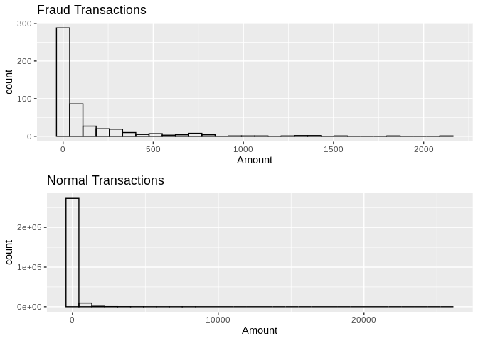

```r
p3 <- ggplot(fraudData, aes(x = Amount)) +
        geom_histogram(fill="light blue", colour = "black") + labs(title=expression("Fraud Transactions"))

p4 <- ggplot(notFraudData, aes(x = Amount)) +
        geom_histogram(fill="light green", colour = "black") + labs(title=expression("Normal Transactions"))

grid.arrange(p3, p4)
```

- No particular insights here, most of the transactions appear to be of small amount for both fraud and clean transactions. Lets further look into it by looking at its percentiles

#### Cumulative quintiles for Fraud and Normal transactions

```r
##Normal Transactions
quantile(notFraudData$Amount, seq(0, 1, by=.2))
```

```
##       0%      20%      40%      60%      80%     100%
##     0.00     3.58    13.03    37.00   100.00 25691.16
```

```r
##Fraud Transactions
quantile(fraudData$Amount, seq(0, 1, by=.2))
```

```
##       0%      20%      40%      60%      80%     100%
##    0.000    1.000    2.000   39.992  152.342 2125.870
```

- Clearly 60% of the transactions are of amount less than ~$40. Lets zoom into the transactions under $50 to see if there is an anomaly between fraud and clean transactions

#### Cumulative % graphs for Normal and Fraud transaction amounts

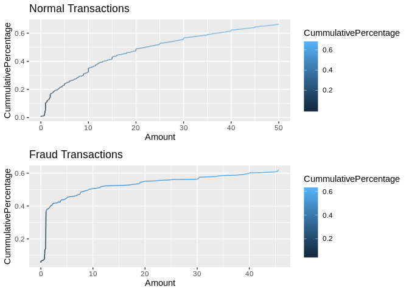

```r
tab <- melt(table(CC_Data$Amount[CC_Data$Class=='Normal']))
tab$CummulativePercentage <- cumsum(tab$value) / sum(tab$value) # cumulative Frequency
names(tab)[1] <- "Amount"
p5 <- ggplot(tab[tab$Amount<50,], aes(x=Amount, y=CummulativePercentage, color=CummulativePercentage))+
  geom_line()+ggtitle("Normal Transactions")

tab <- melt(table(CC_Data$Amount[CC_Data$Class=='Fraud']))
tab$CummulativePercentage <- cumsum(tab$value) / sum(tab$value)
names(tab)[1] <- "Amount"
p6 <- ggplot(tab[tab$Amount<50,], aes(x=Amount, y=CummulativePercentage, color=CummulativePercentage))+
  geom_line()+ggtitle("Fraud Transactions")

grid.arrange(p5, p6)
```

#### 5. Exploring if Fraud Transactions are related with amount and time of transaction?

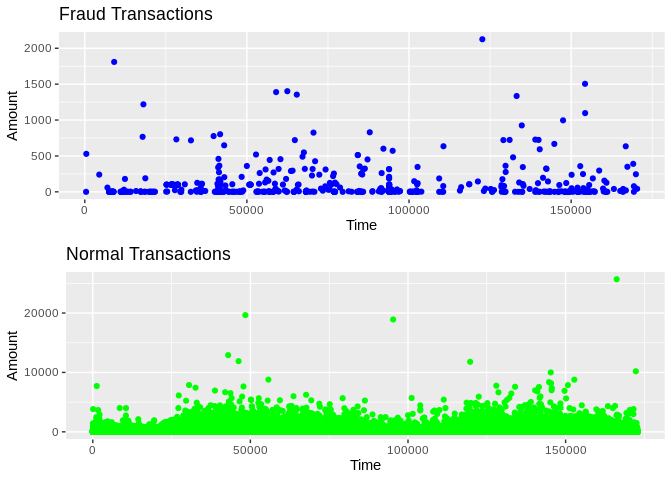

```r
p7<-ggplot(fraudData, aes(x=Time, y=Amount)) +
  geom_point(colour="blue") + ggtitle("Fraud Transactions")

p8<-ggplot(notFraudData, aes(x=Time, y=Amount)) +
  geom_point(colour="green")+ggtitle("Normal Transactions")

grid.arrange(p7, p8)
```

- Again, no particular anomaly here between fraud and normal transactions.

#### 6. Which variables explain the fraud transactions?

**We will use several methods to explore which variables can help in detecting the fraud transaction**

First,we need to look at the coorelation of all variablesto find a relation :

##### Correlation map

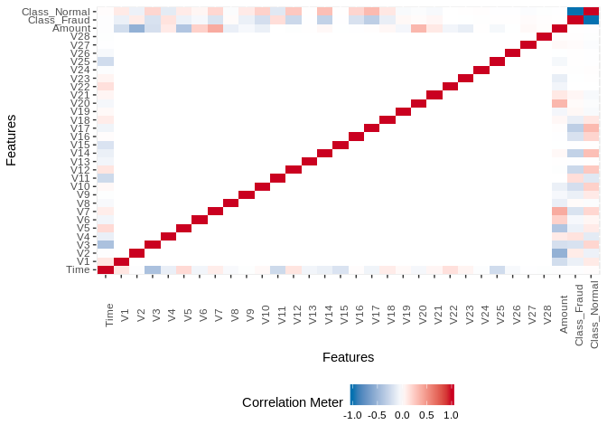

```r
plot_correlation(CC_Data, maxcat = 8L)
```

- None of the V1 to V28 PCA components have any correlation to each other.
- Little to no correlation between variables indicates that it is highly likely that ** data is pca transformed**
- Time has some correlations with V components but not with Amount.
- Amount also has some correlations with V components but not with Time.
- Class has some positive and negative correlations with the V components but has no significant correlation with Time and Amount.

##### Comparison of mean of variables by Fraud vs Normal transactions

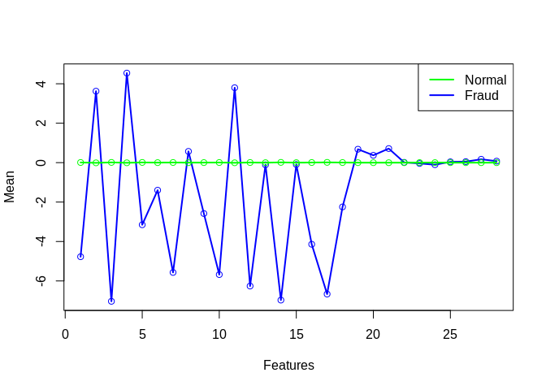

```r
skew <- sum(as.numeric(CC_Data$Class))/nrow(CC_Data)
mugood <- apply(notFraudData[sample(rownames(notFraudData), size = as.integer(skew *nrow(CC_Data)), replace = T), -c(1, 30, 31)], 2, mean)
muanom <- apply(fraudData[, -c(1, 30, 31)], 2, mean)
plot(muanom, col = "blue", xlab = "Features", ylab = "Mean")
lines(muanom, col = "blue", lwd = 2)
points(mugood, col = "green")
lines(mugood, col = "green", lwd = 2)
legend("topright", legend = c("Normal", "Fraud"), lty = c(1,1), col = c("green", "blue"), lwd = c(2,2))
```

- Mean values of variables for fraud transactions are different than for normal transactions for most of the variables.
- Mean values for the normal transacitons dont differ.
- Mean values for fraud transactions differ alot.

**Let’s look at the box plot for all the variables:**

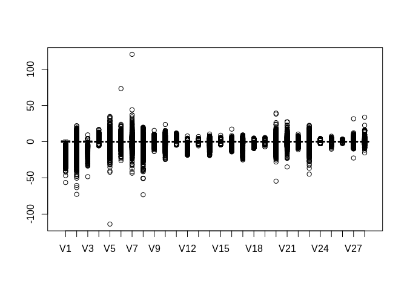

```r
boxplot(CC_Data[2:29])
```

- It is worth noticing that V13, V15, V19, and maybe V24 look very symmetrical. We will look at them in detail below
- Outliers appear to be a problem. However, outliers also help in detecting anomolies so we will not treat them.

# 3. K-Means Clustering

#### Data Preparation

- To prepare the dataset for clustering, we center and scale the columns using scale(x, center = TRUE, scale = TRUE), where x is a matrix or dataframe. -But first subsetting is required.

```r
CC_Data <- read_csv("/home/dcclxxvii/Data/creditcard.csv")
CC_Data_cluster_analysis <- CC_Data[1:1000,]

head(CC_Data_cluster_analysis, n=3)
```

```
## # A tibble: 3 x 31
##    Time    V1      V2    V3    V4      V5      V6      V7     V8     V9     V10
##   <dbl> <dbl>   <dbl> <dbl> <dbl>   <dbl>   <dbl>   <dbl>  <dbl>  <dbl>   <dbl>
## 1     0 -1.36 -0.0728 2.54  1.38  -0.338   0.462   0.240  0.0987  0.364  0.0908
## 2     0  1.19  0.266  0.166 0.448  0.0600 -0.0824 -0.0788 0.0851 -0.255 -0.167
## 3     1 -1.36 -1.34   1.77  0.380 -0.503   1.80    0.791  0.248  -1.51   0.208
## # … with 20 more variables: V11 <dbl>, V12 <dbl>, V13 <dbl>, V14 <dbl>,
## #   V15 <dbl>, V16 <dbl>, V17 <dbl>, V18 <dbl>, V19 <dbl>, V20 <dbl>,
## #   V21 <dbl>, V22 <dbl>, V23 <dbl>, V24 <dbl>, V25 <dbl>, V26 <dbl>,
## #   V27 <dbl>, V28 <dbl>, Amount <dbl>, Class <dbl>
```

```r
CC_Data_scale <- scale(CC_Data_cluster_analysis)

head(CC_Data_cluster_analysis, n=3)
```

```
## # A tibble: 3 x 31
##    Time    V1      V2    V3    V4      V5      V6      V7     V8     V9     V10
##   <dbl> <dbl>   <dbl> <dbl> <dbl>   <dbl>   <dbl>   <dbl>  <dbl>  <dbl>   <dbl>
## 1     0 -1.36 -0.0728 2.54  1.38  -0.338   0.462   0.240  0.0987  0.364  0.0908
## 2     0  1.19  0.266  0.166 0.448  0.0600 -0.0824 -0.0788 0.0851 -0.255 -0.167
## 3     1 -1.36 -1.34   1.77  0.380 -0.503   1.80    0.791  0.248  -1.51   0.208
## # … with 20 more variables: V11 <dbl>, V12 <dbl>, V13 <dbl>, V14 <dbl>,
## #   V15 <dbl>, V16 <dbl>, V17 <dbl>, V18 <dbl>, V19 <dbl>, V20 <dbl>,
## #   V21 <dbl>, V22 <dbl>, V23 <dbl>, V24 <dbl>, V25 <dbl>, V26 <dbl>,
## #   V27 <dbl>, V28 <dbl>, Amount <dbl>, Class <dbl>
```

#### Dtermine OPtimal Number of Columns

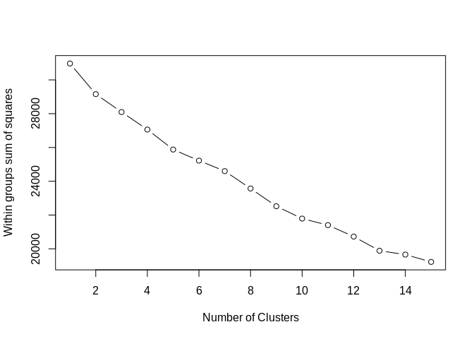

```r
wssplot <- function(data, nc=15, seed=1234){
               wss <- (nrow(data)-1)*sum(apply(data,2,var))
               for (i in 2:nc){
                    set.seed(seed)
                    wss[i] <- sum(kmeans(data, centers=i)$withinss)}
                plot(1:nc, wss, type="b", xlab="Number of Clusters",
                     ylab="Within groups sum of squares")}

wssplot(CC_Data_scale)
```

#### Deterimine optimal number of clusters

-NbClust() is used to determine the best clustering scheme from the different results obtained by varying all combinations of number of clusters and distance methods.

```r
set.seed(1234)
nc <- NbClust(CC_Data_scale, min.nc=2, max.nc=15, method="kmeans")
```

[output not shown]

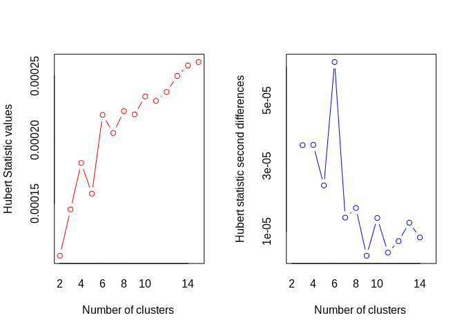

```
## *** : The Hubert index is a graphical method of determining the number of clusters.
##                 In the plot of Hubert index, we seek a significant knee that corresponds to a
##                 significant increase of the value of the measure i.e the significant peak in Hubert
##                 index second differences plot.
##
```

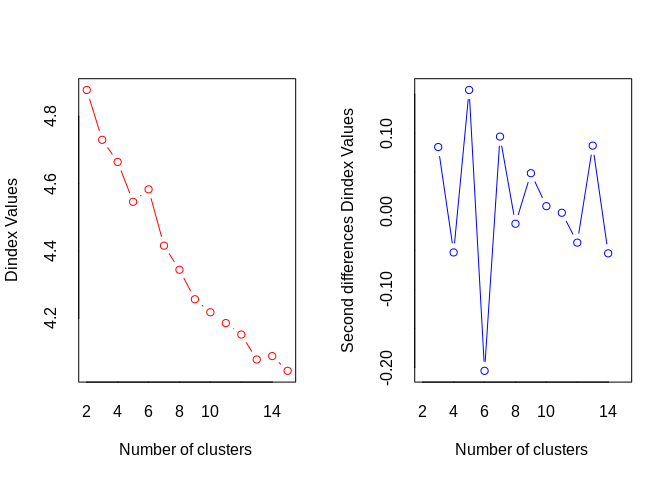

```
## *** : The D index is a graphical method of determining the number of clusters.
##                 In the plot of D index, we seek a significant knee (the significant peak in Dindex
##                 second differences plot) that corresponds to a significant increase of the value of
##                 the measure.
##
## * Among all indices:
## * 8 proposed 2 as the best number of clusters
## * 4 proposed 3 as the best number of clusters
## * 2 proposed 5 as the best number of clusters
## * 1 proposed 6 as the best number of clusters
## * 1 proposed 11 as the best number of clusters
## * 5 proposed 13 as the best number of clusters
## * 1 proposed 14 as the best number of clusters
## * 2 proposed 15 as the best number of clusters
##
##                    ***** Conclusion *****
##
## * According to the majority rule, the best number of clusters is  2
##
##
```

-Optimal number of clusters is determined as the number of clusters selected by the highest number of criteria. This can be visualized as a barplot:

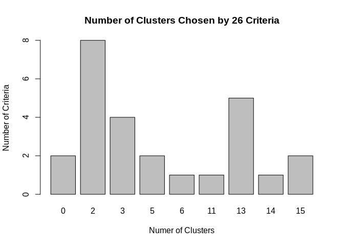

```r
barplot(table(nc$Best.n[1,]),
          xlab="Numer of Clusters", ylab="Number of Criteria",
          main="Number of Clusters Chosen by 26 Criteria")
```

- 2 Is the optimal number of cluster to have

#### K-means cluster analysis

-kmeans() is used to obtain the final clustering solution.

```r
cc_km <- kmeans(CC_Data, 2, nstart=25)
```

-view cluster details

```r
str(cc_km)
```

```
## List of 9
##  $ cluster     : int [1:284807] 1 1 1 1 1 1 1 1 1 1 ...
##  $ centers     : num [1:2, 1:31] 5.50e+04 1.41e+05 -2.35e-01 2.74e-01 4.43e-02 ...
##   ..- attr(*, "dimnames")=List of 2
##   .. ..$ : chr [1:2] "1" "2"
##   .. ..$ : chr [1:31] "Time" "V1" "V2" "V3" ...
##  $ totss       : num 6.42e+14
##  $ withinss    : num [1:2] 7.78e+13 4.05e+13
##  $ tot.withinss: num 1.18e+14
##  $ betweenss   : num 5.24e+14
##  $ size        : int [1:2] 153163 131644
##  $ iter        : int 1
##  $ ifault      : int 0
##  - attr(*, "class")= chr "kmeans"
```

-cluster summary

```r
summary(cc_km)
```

```
##              Length Class  Mode
## cluster      284807 -none- numeric
## centers          62 -none- numeric
## totss             1 -none- numeric
## withinss          2 -none- numeric
## tot.withinss      1 -none- numeric
## betweenss         1 -none- numeric
## size              2 -none- numeric
## iter              1 -none- numeric
## ifault            1 -none- numeric
```

-cc_km$size returns the number of items in each cluster

```r
cc_km$size
```

```
## [1] 153163 131644
```

-cc_km$centers returns the central value for each cluster

```r
cc_km$centers
```

```
##        Time         V1          V2         V3         V4         V5          V6
## 1  55048.79 -0.2353789  0.04427366  0.6076086  0.1332921 -0.2401611  0.06960662
## 2 141079.07  0.2738548 -0.05151079 -0.7069305 -0.1550805  0.2794187 -0.08098477
##           V7          V8          V9         V10        V11         V12
## 1 -0.1040489  0.05267069 -0.03483090 -0.02964435  0.2095483 -0.03225236
## 2  0.1210571 -0.06128043  0.04052448  0.03449012 -0.2438019  0.03752444
##           V13         V14        V15         V16         V17         V18
## 1  0.02891077  0.05617186  0.1822972 -0.01185768  0.04383290 -0.07095215
## 2 -0.03363663 -0.06535392 -0.2120961  0.01379598 -0.05099799  0.08255024
##           V19         V20         V21        V22         V23         V24
## 1 -0.02118225  0.03952270 -0.03721361 -0.1097482 -0.02858757  0.01170539
## 2  0.02464478 -0.04598322  0.04329668  0.1276880  0.03326060 -0.01361880
##          V25         V26          V27          V28   Amount       Class
## 1  0.1166436  0.02295955  0.001875054  0.002853748 88.65190 0.002154567
## 2 -0.1357106 -0.02671260 -0.002181557 -0.003320232 87.99793 0.001230592
```

```r
aggregate(CC_Data[-1], by=list(cluster=cc_km$cluster),mean)
```

```
##   cluster         V1          V2         V3         V4         V5          V6
## 1       1 -0.2353789  0.04427366  0.6076086  0.1332921 -0.2401611  0.06960662
## 2       2  0.2738548 -0.05151079 -0.7069305 -0.1550805  0.2794187 -0.08098477
##           V7          V8          V9         V10        V11         V12
## 1 -0.1040489  0.05267069 -0.03483090 -0.02964435  0.2095483 -0.03225236
## 2  0.1210571 -0.06128043  0.04052448  0.03449012 -0.2438019  0.03752444
##           V13         V14        V15         V16         V17         V18
## 1  0.02891077  0.05617186  0.1822972 -0.01185768  0.04383290 -0.07095215
## 2 -0.03363663 -0.06535392 -0.2120961  0.01379598 -0.05099799  0.08255024
##           V19         V20         V21        V22         V23         V24
## 1 -0.02118225  0.03952270 -0.03721361 -0.1097482 -0.02858757  0.01170539
## 2  0.02464478 -0.04598322  0.04329668  0.1276880  0.03326060 -0.01361880
##          V25         V26          V27          V28   Amount       Class
## 1  0.1166436  0.02295955  0.001875054  0.002853748 88.65190 0.002154567
## 2 -0.1357106 -0.02671260 -0.002181557 -0.003320232 87.99793 0.001230592
```

-plot the cluster

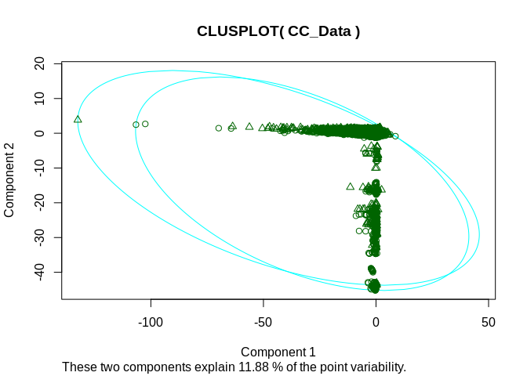

```r
clusplot(CC_Data, cc_km$cluster)
```

# 4. ANN (Artificial Neural Network)

- Load the neuralnet package into the system.

```r
library("neuralnet")
```

```r
CC_Data_nn_scaled<- CC_Data[1:10000,]
```

```r
summary(CC_Data_nn_scaled)
```

```
##       Time             V1                 V2                 V3
##  Min.   :    0   Min.   :-27.6706   Min.   :-34.6076   Min.   :-15.4962
##  1st Qu.: 2073   1st Qu.: -1.0133   1st Qu.: -0.2083   1st Qu.:  0.4128
##  Median : 4564   Median : -0.3728   Median :  0.2885   Median :  0.9444
##  Mean   : 5966   Mean   : -0.2419   Mean   :  0.2819   Mean   :  0.9063
##  3rd Qu.:10233   3rd Qu.:  1.1509   3rd Qu.:  0.9019   3rd Qu.:  1.6029
##  Max.   :15012   Max.   :  1.9605   Max.   :  8.6362   Max.   :  4.1017
##        V4                V5                 V6                 V7
##  Min.   :-4.6575   Min.   :-32.0921   Min.   :-23.4967   Min.   :-26.54814
##  1st Qu.:-0.6144   1st Qu.: -0.6434   1st Qu.: -0.6299   1st Qu.: -0.54234
##  Median : 0.2199   Median : -0.1528   Median : -0.1526   Median : -0.05559
##  Mean   : 0.2641   Mean   : -0.0464   Mean   :  0.1331   Mean   : -0.07169
##  3rd Qu.: 1.1257   3rd Qu.:  0.3711   3rd Qu.:  0.5054   3rd Qu.:  0.47628
##  Max.   :10.4630   Max.   : 34.0993   Max.   : 21.3931   Max.   : 34.30318
##        V8                  V9                V10                V11
##  Min.   :-23.63250   Min.   :-6.32980   Min.   :-13.1934   Min.   :-2.59532
##  1st Qu.: -0.19075   1st Qu.: 0.07087   1st Qu.: -0.6884   1st Qu.:-0.06369
##  Median :  0.01286   Median : 0.80527   Median : -0.3407   Median : 0.74675
##  Mean   : -0.06478   Mean   : 0.80222   Mean   : -0.2230   Mean   : 0.76607
##  3rd Qu.:  0.27453   3rd Qu.: 1.50630   3rd Qu.:  0.1743   3rd Qu.: 1.57654
##  Max.   :  5.06038   Max.   :10.39289   Max.   : 12.2599   Max.   :12.01891
##       V12                 V13                V14                V15
##  Min.   :-17.76914   Min.   :-3.38951   Min.   :-19.2143   Min.   :-4.15253
##  1st Qu.: -2.36811   1st Qu.:-0.01798   1st Qu.:  0.0804   1st Qu.:-0.70953
##  Median : -1.62102   Median : 0.91913   Median :  0.8998   Median :-0.01008
##  Mean   : -1.27251   Mean   : 0.85141   Mean   :  0.7006   Mean   :-0.12963
##  3rd Qu.:  0.08267   3rd Qu.: 1.76889   3rd Qu.:  1.4992   3rd Qu.: 0.53350
##  Max.   :  3.77484   Max.   : 4.46541   Max.   :  5.7487   Max.   : 3.63504
##       V16                  V17                V18                V19
##  Min.   :-12.227189   Min.   :-18.5874   Min.   :-6.92076   Min.   :-4.93273
##  1st Qu.: -0.495536   1st Qu.: -0.1800   1st Qu.:-0.45030   1st Qu.:-0.55213
##  Median :  0.066086   Median :  0.2974   Median : 0.02523   Median :-0.07721
##  Mean   : -0.007757   Mean   :  0.3190   Mean   :-0.01607   Mean   :-0.07042
##  3rd Qu.:  0.547399   3rd Qu.:  0.7829   3rd Qu.: 0.45939   3rd Qu.: 0.44291
##  Max.   :  4.087802   Max.   :  7.8934   Max.   : 4.11556   Max.   : 4.55536
##       V20                 V21                 V22               V23
##  Min.   :-13.27603   Min.   :-11.46843   Min.   :-8.5271   Min.   :-15.14434
##  1st Qu.: -0.14998   1st Qu.: -0.26812   1st Qu.:-0.5496   1st Qu.: -0.17412
##  Median : -0.02142   Median : -0.12327   Median :-0.1367   Median : -0.04579
##  Mean   :  0.02751   Mean   : -0.05199   Mean   :-0.1527   Mean   : -0.03327
##  3rd Qu.:  0.15653   3rd Qu.:  0.03271   3rd Qu.: 0.2475   3rd Qu.:  0.08167
##  Max.   :  8.01257   Max.   : 22.58899   Max.   : 4.5345   Max.   : 13.87622
##       V24                V25                V26                V27
##  Min.   :-2.51238   Min.   :-2.57736   Min.   :-1.33856   Min.   :-7.976100
##  1st Qu.:-0.32782   1st Qu.:-0.15814   1st Qu.:-0.32797   1st Qu.:-0.084489
##  Median : 0.07998   Median : 0.12100   Median : 0.04287   Median :-0.004568
##  Mean   : 0.02133   Mean   : 0.08715   Mean   : 0.10814   Mean   : 0.005518
##  3rd Qu.: 0.41088   3rd Qu.: 0.35906   3rd Qu.: 0.47639   3rd Qu.: 0.120811
##  Max.   : 3.20020   Max.   : 5.52509   Max.   : 3.51735   Max.   : 8.254376
##       V28                Amount            Class
##  Min.   :-3.509250   Min.   :   0.00   Min.   :0.0000
##  1st Qu.:-0.015753   1st Qu.:   5.00   1st Qu.:0.0000
##  Median : 0.015897   Median :  15.95   Median :0.0000
##  Mean   : 0.002915   Mean   :  63.03   Mean   :0.0038
##  3rd Qu.: 0.077182   3rd Qu.:  50.96   3rd Qu.:0.0000
##  Max.   : 4.860769   Max.   :7712.43   Max.   :1.0000
```

-The following code splits the dataset into a training set consisting of 70% of the data and a test set containing 30% of the data.

```r
ind <- sample(2, nrow(CC_Data_nn_scaled), replace = TRUE, prob = c(0.7, 0.3))
train.data <- as.data.frame(CC_Data_nn_scaled[ind == 1, ])
test.data <- as.data.frame(CC_Data_nn_scaled[ind == 2, ])
```

-This command implements the neural network method on training data using class as the dependent variable and all other variables as independent variables. We use one hidden layer with 2 nodes, and linear output set tofalse for classification models. - From the analysis of the variable correaltion with the fraud class we chose only those which showed correlation

```r
nn <- neuralnet(formula = Class ~ V1 + V3 + V4 + V6 + V9 + V10 + V11 + V12 + V14 + V16 + V18,
                data = train.data, hidden = 2, linear.output = FALSE)
```

-Summary of the model

```r
summary(nn)
```

```
##                     Length Class      Mode
## call                    5  -none-     call
## response             6967  -none-     numeric
## covariate           76637  -none-     numeric
## model.list              2  -none-     list
## err.fct                 1  -none-     function
## act.fct                 1  -none-     function
## linear.output           1  -none-     logical
## data                   31  data.frame list
## exclude                 0  -none-     NULL
## net.result              1  -none-     list
## weights                 1  -none-     list
## generalized.weights     1  -none-     list
## startweights            1  -none-     list
## result.matrix          30  -none-     numeric
```

-We will examine the following properties: the response values, result matrix, and net result probabilities. -Show the values of the dependent variable for the first 21 observations.

```r
nn$response[1:21]
```

```
##  [1] 0 0 0 0 0 0 0 0 0 0 0 0 0 0 0 0 0 0 0 0 0
```

-Show the probability for the first 21 records.

```r
nn$net.result[[1]][1:21]
```

```
##  [1] 1.364469e-05 1.295580e-05 1.304367e-05 1.342268e-05 1.298152e-05
##  [6] 1.343188e-05 1.293815e-05 1.341629e-05 1.292675e-05 9.429421e-05
## [11] 2.117496e-05 1.284071e-05 1.349765e-05 1.379354e-05 1.294001e-05
## [16] 1.319319e-05 1.286617e-05 1.522678e-05 2.720727e-05 1.287460e-05
## [21] 1.696066e-05
```

-Show the network result matrix, which includes information on the number of training steps, the error, and the weights.

```r
nn$result.matrix
```

```
##                               [,1]
## error                  0.507580492
## reached.threshold      0.009780447
## steps                 76.000000000
## Intercept.to.1layhid1  6.256267595
## V1.to.1layhid1        -0.103279651
## V3.to.1layhid1         0.653418135
## V4.to.1layhid1        -0.687601862
## V6.to.1layhid1         0.416831608
## V9.to.1layhid1        -0.029453120
## V10.to.1layhid1       -0.221228719
## V11.to.1layhid1        1.204695496
## V12.to.1layhid1        1.115560623
## V14.to.1layhid1        0.668852795
## V16.to.1layhid1       -0.018959563
## V18.to.1layhid1        1.128814874
## Intercept.to.1layhid2  5.655895839
## V1.to.1layhid2        -0.412938385
## V3.to.1layhid2         0.051582406
## V4.to.1layhid2        -0.118592679
## V6.to.1layhid2         0.976239092
## V9.to.1layhid2         1.069864706
## V10.to.1layhid2        0.873704180
## V11.to.1layhid2        0.565121127
## V12.to.1layhid2        0.823114665
## V14.to.1layhid2        1.149523981
## V16.to.1layhid2        1.401667037
## V18.to.1layhid2        0.999098290
## Intercept.to.Class     3.926103952
## 1layhid1.to.Class     -7.548818134
## 1layhid2.to.Class     -7.641725650
```

-Create a visualization of the neural network.

```r
plot(nn)
```

[output not shown]

- Compute the predicted values for the training set

```r
mypredict <- compute(nn, nn$covariate)$net.result
mypredict <- apply(mypredict, c(1), round)
```

-Show the first 21 predicted values.

```r
mypredict[1:21]
```

```
##  [1] 0 0 0 0 0 0 0 0 0 0 0 0 0 0 0 0 0 0 0 0 0
```

-Create the confusion matrix on the training data.

```r
table(mypredict, train.data$Class, dnn = c("Predicted", "Actual"))
```

```
##          Actual
## Predicted    0    1
##         0 6936    1
##         1    0   30
```

```r
testPred <- compute(nn, test.data)$net.result
testPred <- apply(testPred, c(1), round)
```

-Create the confusion matrix on the test data.

```r
table(testPred, test.data$Class, dnn = c("Predicted", "Actual"))
```

```
##          Actual
## Predicted    0    1
##         0 3026    1
##         1    0    6
```